# 05_downstream_analyses_pups

Anna Chamot

2025-06-27

# ATAC-seq: Post-DAA functional follow-up analyses

This notebook contains downstream analyses following differential chromatin accessibility in PND15 spermatogonial stem cells, including peak annotation, motif and pathway enrichment, and integration with RNA-seq.

## 5.0 Setup and imports

```r
# All required libraries for downstream annotation, plotting, pathway, motif analyses
suppressPackageStartupMessages({
  library(SummarizedExperiment)
  library(dplyr)
  library(ggplot2)
  library(cowplot)
  library(reshape2)
  library(EnhancedVolcano)
  library(pheatmap)
  library(dichromat)
  library(gprofiler2)
  library(limma)
  library(rtracklayer)
  library(ChIPseeker)
  library(TxDb.Mmusculus.UCSC.mm10.knownGene)
  library(org.Mm.eg.db)
  library(EnsDb.Mmusculus.v79)
  library(BSgenome.Mmusculus.UCSC.mm10)
  library(memes)
  library(tibble)
  library(dorothea)
})
```

## 5.1 Parameters, inputs, outputs

```r
# Main directories and experimental settings (customize as needed)
outputdir <- "/mnt/groupMansuy/anna/Bioinformatics_project/ATAC/results/dea_04/"
strain <- "B6"
generation <- "F1"
sex <- "Male"
Sub_age <- "P15"
suffix <- "Basemodel"
pthreshold <- 0.05
logthreshold <- 0.5

dirname <- paste0(strain, "-", generation, "-", sex, "-", Sub_age, "-", suffix, "/")
output <- paste0(outputdir, dirname)
if (!dir.exists(output)) dir.create(output, recursive = TRUE)
```

## 5.2 Load differential accessibility results

```r
# Load SummarizedExperiment from previous DEA
SE <- readRDS(file = paste0(output, "SE_final.rds"))
```

## 5.3 Export Up/Downregulated peaks as BED

```r
# Identify significantly up/down-regulated peaks
up <- SE[rowData(SE)$dea$padj < pthreshold & rowData(SE)$dea$logFC > logthreshold]
down <- SE[rowData(SE)$dea$padj < pthreshold & rowData(SE)$dea$logFC < -logthreshold]

# Extract GenomicRanges for up/down peaks
up.ranges <- granges(up)
down.ranges <- granges(down)

# Format BED: seqnames, start-1, end, strand
up.ranges.df <- data.frame(seqnames=seqnames(up.ranges), starts=start(up.ranges)-1, ends=end(up.ranges), strands=strand(up.ranges))
down.ranges.df <- data.frame(seqnames=seqnames(down.ranges), starts=start(down.ranges)-1, ends=end(down.ranges), strands=strand(down.ranges))

# Write BED files
write.table(up.ranges.df, file=paste0(output,"up.bed"), quote=F, sep="\t", row.names=F, col.names=F)
write.table(down.ranges.df, file=paste0(output,"down.bed"), quote=F, sep="\t", row.names=F, col.names=F)
```

## 5.4 Merge BAM files by condition (for downstream signal plotting)

```r
# Sample lists by group
ctrBam <- colData(SE)$bamReads[colData(SE)$Condition == "Control"]
msusBam <- colData(SE)$bamReads[colData(SE)$Condition == "MSUS"]
```

```r
# Merge and index BAMs (system calls; check samtools availability)
system(paste0("samtools merge -@ 8 ", output, "ctrMerged.bam ", paste(ctrBam, collapse = " ")))
system(paste0("samtools index ", output, "ctrMerged.bam"))
system(paste0("samtools merge -@ 8 ", output, "msusMerged.bam ", paste(msusBam, collapse = " ")))
system(paste0("samtools index ", output, "msusMerged.bam"))
```

## 5.5 Generate signal tracks and heatmaps

```bash
# Merge BAM → bigWig (use your tracks.sh or other bigWig generator)
/mnt/groupMansuy/anna/Bioinformatics_project/tracks.sh /mnt/groupMansuy/anna/Bioinformatics_project/ATAC/results/dea_04/B6-F1-Male-P15-Basemodel/ctrMerged.bam /mnt/groupMansuy/anna/Bioinformatics_project/ATAC/results/dea_04/B6-F1-Male-P15-Basemodel/ /mnt/groupMansuy/anna/Bioinformatics_project/ATAC/results/dea_04/B6-F1-Male-P15-Basemodel/logs/41_mergedtracks/ 5 8

/mnt/groupMansuy/anna/Bioinformatics_project/tracks.sh /mnt/groupMansuy/anna/Bioinformatics_project/ATAC/results/dea_04/B6-F1-Male-P15-Basemodel/msusMerged.bam /mnt/groupMansuy/anna/Bioinformatics_project/ATAC/results/dea_04/B6-F1-Male-P15-Basemodel/ /mnt/groupMansuy/anna/Bioinformatics_project/ATAC/results/dea_04/B6-F1-Male-P15-Basemodel/logs/41_mergedtracks/ 5 8

# Compute matrix for up/down peaks and plot heatmap
computeMatrix reference-point -R /mnt/groupMansuy/anna/Bioinformatics_project/ATAC/results/dea_04/B6-F1-Male-P15-Basemodel/up.bed /mnt/groupMansuy/anna/Bioinformatics_project/ATAC/results/dea_04/B6-F1-Male-P15-Basemodel/down.bed --referencePoint "center" -S /mnt/groupMansuy/anna/Bioinformatics_project/ATAC/results/dea_04/B6-F1-Male-P15-Basemodel/ctrMerged.bw /mnt/groupMansuy/anna/Bioinformatics_project/ATAC/results/dea_04/B6-F1-Male-P15-Basemodel/msusMerged.bw -b 1000 -a 1000 --skipZeros -p 8 -o /mnt/groupMansuy/anna/Bioinformatics_project/ATAC/results/dea_04/B6-F1-Male-P15-Basemodel/DAR.mat.gz --outFileSortedRegions /mnt/groupMansuy/anna/Bioinformatics_project/ATAC/results/dea_04/B6-F1-Male-P15-Basemodel/DAR.bed

plotHeatmap -m /mnt/groupMansuy/anna/Bioinformatics_project/ATAC/results/dea_04/B6-F1-Male-P15-Basemodel/DAR.mat.gz --refPointLabel "Peak center" --plotFileFormat "pdf" --colorMap 'Greys' --whatToShow 'heatmap and colorbar' --heatmapHeight 10 -out /mnt/groupMansuy/anna/Bioinformatics_project/ATAC/results/dea_04/B6-F1-Male-P15-Basemodel/DAR.heatmap.pdf
```

[figure not shown]

## 5.6 Motif Enrichment [AME + HOMER]

```bash
# With HOMER
bed2pos.pl /mnt/groupMansuy/anna/Bioinformatics_project/ATAC/results/dea_04/B6-F1-Male-P15-Basemodel/up.bed > /mnt/groupMansuy/anna/Bioinformatics_project/ATAC/results/dea_04/B6-F1-Male-P15-Basemodel/up.pos

findMotifsGenome.pl /mnt/groupMansuy/anna/Bioinformatics_project/ATAC/results/dea_04/B6-F1-Male-P15-Basemodel/up.pos mm10 /mnt/groupMansuy/anna/Bioinformatics_project/ATAC/results/dea_04/B6-F1-Male-P15-Basemodel/up -preparsedDir /mnt/groupMansuy/anna/Bioinformatics_project/ATAC/results/dea_04/B6-F1-Male-P15-Basemodel/preparsed/ -size 200 -mask -p 8

bed2pos.pl /mnt/groupMansuy/anna/Bioinformatics_project/ATAC/results/dea_04/B6-F1-Male-P15-Basemodel/down.bed > /mnt/groupMansuy/anna/Bioinformatics_project/ATAC/results/dea_04/B6-F1-Male-P15-Basemodel/down.pos

findMotifsGenome.pl /mnt/groupMansuy/anna/Bioinformatics_project/ATAC/results/dea_04/B6-F1-Male-P15-Basemodel/down.pos mm10 /mnt/groupMansuy/anna/Bioinformatics_project/ATAC/results/dea_04/B6-F1-Male-P15-Basemodel/down -preparsedDir /mnt/groupMansuy/anna/Bioinformatics_project/ATAC/results/dea_04/B6-F1-Male-P15-Basemodel/preparsed/ -size 200 -mask -p 8
```

```r
# Enriched motifs corresponding to the up-regulated peaks
homer_results_up <- read.delim(paste0(output,"up/knownResults.txt"), header = TRUE, stringsAsFactors = FALSE)
head(homer_results_up[, c("Motif.Name", "Consensus", "P.value", "q.value..Benjamini.")], 1)
```

```
##                                        Motif.Name       Consensus P.value
## 1 DMRT6(DM)/Testis-DMRT6-ChIP-Seq(GSE60440)/Homer YDGHTACAWTGTADC   0.001
##   q.value..Benjamini.
## 1              0.3964
```

```r
# Enriched motifs corresponding to the down-regulated peaks
homer_results_down <- read.delim(paste0(output,"down/knownResults.txt"), header = TRUE, stringsAsFactors = FALSE)
head(homer_results_down[, c("Motif.Name", "Consensus", "P.value", "q.value..Benjamini.")], 5)
```

```
##                                              Motif.Name       Consensus P.value
## 1   Stat3+il21(Stat)/CD4-Stat3-ChIP-Seq(GSE19198)/Homer  SVYTTCCNGGAARB   1e-05
## 2        Stat3(Stat)/mES-Stat3-ChIP-Seq(GSE11431)/Homer      CTTCCGGGAA   1e-04
## 3        STAT4(Stat)/CD4-Stat4-ChIP-Seq(GSE22104)/Homer    NYTTCCWGGAAR   1e-04
## 4      STAT5(Stat)/mCD4+-Stat5-ChIP-Seq(GSE12346)/Homer    RTTTCTNAGAAA   1e-03
## 5 ZNF143|STAF(Zf)/CUTLL-ZNF143-ChIP-Seq(GSE29600)/Homer ATTTCCCAGVAKSCY   1e-02
##   q.value..Benjamini.
## 1              0.0043
## 2              0.0054
## 3              0.0060
## 4              0.0509
## 5              0.1252
```

```r
# With MEME/AME tools
# Extract sequences from the genome (use the appropriate genome, here mouse mm10)
down.sequences <- getSeq(BSgenome.Mmusculus.UCSC.mm10, down.ranges)
up.sequences <- getSeq(BSgenome.Mmusculus.UCSC.mm10, up.ranges)

# Save the sequences in FASTA format for use with AME
Biostrings::writeXStringSet(down.sequences, filepath = paste0(output, "down_sequences.fasta"))
Biostrings::writeXStringSet(up.sequences, filepath = paste0(output, "up_sequences.fasta"))

# Run AME with the input sequences and background sequences
ame_results <- runAme(input = paste0(output, "down_sequences.fasta"), control = "shuffle",
  database = "/mnt/groupMansuy/leo/references/JASPAR/JASPAR2024_CORE.meme", outdir = paste0(output, "ame_output_down"), meme_path = "/mnt/IM/meme/bin/", evalue_report_threshold = 0.05)

ame_results <- runAme(input = paste0(output, "up_sequences.fasta"), control = "shuffle", database = "/mnt/groupMansuy/leo/references/JASPAR/JASPAR2024_CORE.meme", outdir = paste0(output, "ame_output_up"), meme_path = "/mnt/IM/meme/bin/", evalue_report_threshold = 0.05)
```

```
## AME detected no enrichment
```

```r
# Read the AME results .tsv file, for up-regulated peaks
ame_results <- read.delim(paste0(output, "ame_output_up/ame.tsv"), header = TRUE)
print(dim(ame_results))
```

```
## [1] 2 1
```

```r
# Read the AME results .tsv file, for down-regulated peaks
ame_results <- read.delim(paste0(output, "ame_output_down/ame.tsv"), header = TRUE)
head(ame_results[, c("motif_alt_ID", "consensus", "p.value", "adj_p.value")], 5)
```

```
##   motif_alt_ID  consensus  p.value adj_p.value
## 1        Stat4 TTCYRGGAAR 1.76e-08    3.39e-06
## 2        STAT3  TTCYKGGAA 2.46e-08    5.59e-06
## 3         KLF1   GGGYGGGG 3.80e-08    8.86e-06
## 4        STAT1  TTCYRGGAA 8.06e-08    9.51e-06
## 5       Stat5b  TTCCCAGAA 5.54e-08    1.16e-05
```

## 5.7 Correlate ATAC-seq and RNA-seq results

```r
# Load and annotate peaks with nearest gene using ChIPseeker
atac.res.ranges <- granges(SE)
txdb <- TxDb.Mmusculus.UCSC.mm10.knownGene
peaks.anno.atac.res <- annotatePeak(atac.res.ranges, tssRegion = c(-3000, 3000), TxDb = txdb, annoDb = "org.Mm.eg.db")
```

```
## >> preparing features information...      2025-06-30 15:30:22
## >> identifying nearest features...        2025-06-30 15:30:24
## >> calculating distance from peak to TSS...   2025-06-30 15:30:28
## >> assigning genomic annotation...        2025-06-30 15:30:28
## >> adding gene annotation...          2025-06-30 15:30:50
```

```
## >> assigning chromosome lengths           2025-06-30 15:30:51
## >> done...                    2025-06-30 15:30:51
```

```r
df.atac <- as.data.frame(peaks.anno.atac.res@anno)
df.atac.prom <- subset(df.atac, grepl("Promoter", annotation))

# Load RNA-seq SummarizedExperiment
SE.RNA <- readRDS("/mnt/IM/groupMansuy/theresa/RNAseq/MSUS39F1_SC/results_mm10/03_dea/results/PND15_Basemodel/SE.rds")
res.rna <- as.data.frame(rowData(SE.RNA))
res.rna <- rownames_to_column(res.rna, var = "ENSEMBL")

# Join ATAC promoter peaks to RNA-seq results by gene ENSEMBL ID
df.combined <- left_join(df.atac.prom, res.rna, by = "ENSEMBL")
df.combined <- df.combined[!is.na(df.combined$dea.logFC.y),]
```

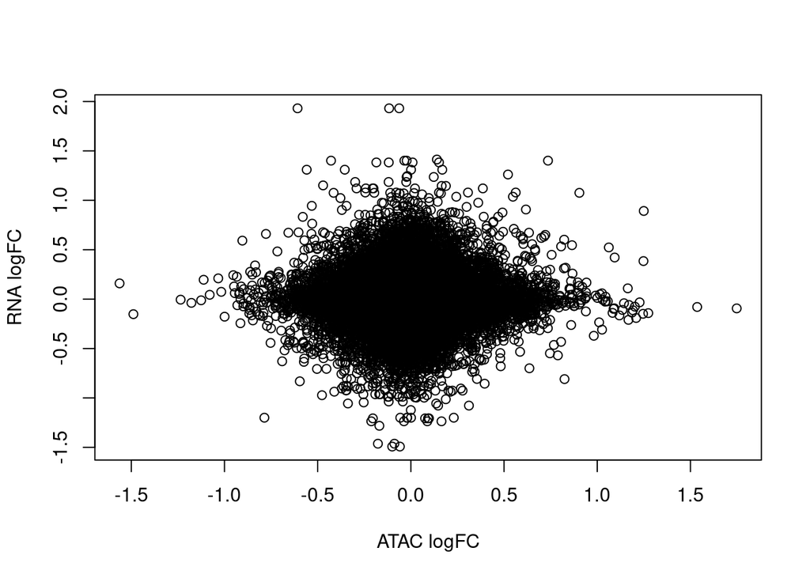

```r
# Correlation: all promoters
plot(df.combined$dea.logFC.x, df.combined$dea.logFC.y, xlab="ATAC logFC", ylab="RNA logFC")
```

```r
cor.test(df.combined$dea.logFC.x, df.combined$dea.logFC.y)
```

```
##
##  Pearson's product-moment correlation
##
## data:  df.combined$dea.logFC.x and df.combined$dea.logFC.y
## t = 3.3836, df = 35238, p-value = 0.0007163
## alternative hypothesis: true correlation is not equal to 0
## 95 percent confidence interval:
##  0.007582466 0.028457240
## sample estimates:
##        cor
## 0.01802182
```

```r
# Significant ATAC, what proportion also significant in RNA?
df.combined.sign.atac <- df.combined[df.combined$dea.padj.x < pthreshold,]
sum(df.combined.sign.atac$dea.padj.y < pthreshold) / nrow(df.combined.sign.atac)
```

```
## [1] 0
```

```r
# Significant RNA, what proportion also significant in ATAC?
df.combined.sign.rna <- df.combined[df.combined$dea.padj.y < pthreshold,]
sum(df.combined.sign.rna$dea.padj.x < pthreshold) / nrow(df.combined.sign.rna)
```

```
## [1] 0
```

```r
# Both significant
df.combined.sign.both <- df.combined[df.combined$dea.padj.x < pthreshold & df.combined$dea.padj.y < pthreshold,]
dim(df.combined.sign.both)
```

```
## [1]  0 27
```

## 5.8 Export differential genes for heatmaps (for deepTools etc.)

```r
# Get differentially expressed genes (padj and/or PValue)
res <- res.rna
colnames(res) <- gsub("^dea\\.", "", colnames(res))

# By adjusted p-value
res.up <- res[res$padj < pthreshold & res$logFC > logthreshold,]
res.down <- res[res$padj < pthreshold & res$logFC < -logthreshold,]

entrez_ids_up <- mapIds(org.Mm.eg.db, keys = res.up$ENSEMBL, column = "ENTREZID", keytype = "ENSEMBL", multiVals = "first")
entrez_ids_down <- mapIds(org.Mm.eg.db, keys = res.down$ENSEMBL, column = "ENTREZID", keytype = "ENSEMBL", multiVals = "first")

# Whole gene and gene start BEDs
genes <- genes(TxDb.Mmusculus.UCSC.mm10.knownGene)
genes.up <- genes[genes$gene_id %in% entrez_ids_up]
genes.down <- genes[genes$gene_id %in% entrez_ids_down]
export.bed(genes.up, con = paste0(output, "genes.up.bed"))
export.bed(genes.down, con = paste0(output, "genes.down.bed"))

genes.start.up <- genes.up; end(genes.start.up) <- start(genes.start.up)
genes.start.down <- genes.down; end(genes.start.down) <- start(genes.start.down)
export.bed(genes.start.up, con = paste0(output, "genes.start.up.bed"))
export.bed(genes.start.down, con = paste0(output, "genes.start.down.bed"))
```

## 5.9 Pathway analysis of differentially accessible genes

```r
# Annotate peak-associated promoters for GO enrichment (using g:Profiler)
peaks.anno.up <- annotatePeak(readPeakFile(paste0(output, "up.bed")), tssRegion = c(-3000, 3000), TxDb = txdb, annoDb = "org.Mm.eg.db")
```

```
## >> preparing features information...      2025-06-30 15:30:55
## >> identifying nearest features...        2025-06-30 15:30:55
## >> calculating distance from peak to TSS...   2025-06-30 15:30:55
## >> assigning genomic annotation...        2025-06-30 15:30:55
## >> adding gene annotation...          2025-06-30 15:30:57
```

```
## >> assigning chromosome lengths           2025-06-30 15:30:57
## >> done...                    2025-06-30 15:30:57
```

```r
peaks.anno.down <- annotatePeak(readPeakFile(paste0(output, "down.bed")), tssRegion = c(-3000, 3000), TxDb = txdb, annoDb = "org.Mm.eg.db")
```

```
## >> preparing features information...      2025-06-30 15:30:57
## >> identifying nearest features...        2025-06-30 15:30:57
## >> calculating distance from peak to TSS...   2025-06-30 15:30:58
## >> assigning genomic annotation...        2025-06-30 15:30:58
## >> adding gene annotation...          2025-06-30 15:31:00
```

```
## >> assigning chromosome lengths           2025-06-30 15:31:00
## >> done...                    2025-06-30 15:31:00
```

```r
promoter_peaks.up <- subset(as.data.frame(peaks.anno.up), grepl("Promoter", annotation))
promoter_peaks.down <- subset(as.data.frame(peaks.anno.down), grepl("Promoter", annotation))
promoter_peaks.merged <- rbind(promoter_peaks.up, promoter_peaks.down)

go_up <- gost(query = promoter_peaks.up$ENSEMBL, organism = "mmusculus", ordered_query = FALSE, multi_query = FALSE, significant = TRUE, exclude_iea = FALSE, measure_underrepresentation = FALSE, evcodes = TRUE, user_threshold = 0.05, correction_method = "g_SCS", domain_scope = "annotated", custom_bg = NULL, numeric_ns = "", sources = "GO:BP", as_short_link = FALSE, highlight = TRUE)
```

```
## No results to show
## Please make sure that the organism is correct or set significant = FALSE
```

```r
go_down <- gost(query = promoter_peaks.down$ENSEMBL, organism = "mmusculus", ordered_query = FALSE, multi_query = FALSE, significant = TRUE, exclude_iea = FALSE, measure_underrepresentation = FALSE, evcodes = TRUE, user_threshold = 0.05, correction_method = "g_SCS", domain_scope = "annotated", custom_bg = NULL, numeric_ns = "", sources = "GO:BP", as_short_link = FALSE, highlight = TRUE)
```

```
## No results to show
## Please make sure that the organism is correct or set significant = FALSE
```

```r
go_merged <- gost(query = promoter_peaks.merged$ENSEMBL, organism = "mmusculus", ordered_query = FALSE, multi_query = FALSE, significant = TRUE, exclude_iea = FALSE, measure_underrepresentation = FALSE, evcodes = TRUE, user_threshold = 0.05, correction_method = "g_SCS", domain_scope = "annotated", custom_bg = NULL, numeric_ns = "", sources = "GO:BP", as_short_link = FALSE, highlight = TRUE)
```

```
## No results to show
## Please make sure that the organism is correct or set significant = FALSE
```

## 5.10 Motif Enrichment: TFs & Target Regulation in RNA-seq

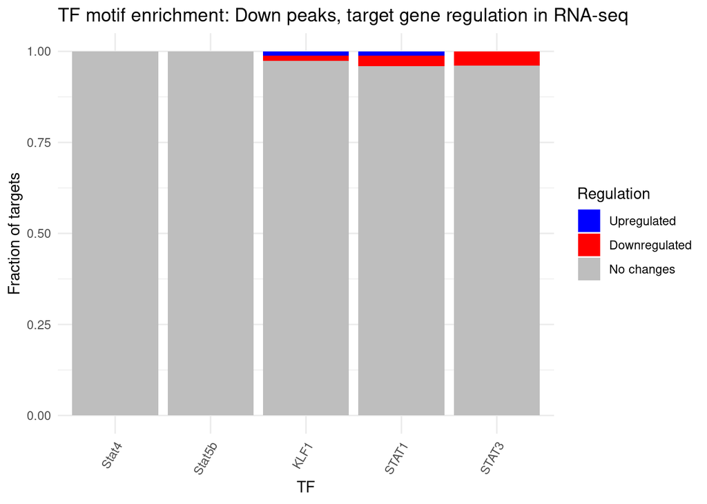

```r
# Use dorothea for TF target annotation
dorothea <- dorothea_mm[dorothea_mm$confidence %in% c("A", "B", "C", "D", "E"),]

# Example: load top TF motifs from AME output for downregulated peaks
tf.down <- read.delim(paste0(output, "ame_output_down/ame.tsv"))
topTFs <- 5
summarycols <- c("TF", "TargetsTotal", "TargetsInRNA", "TargetsPValueSign", "TargetsPadjSign", "Up", "Down", "NoChange", "PercUp", "PercDown", "PercNoChange")
summary.down <- as.data.frame(matrix(NA, nrow = topTFs, ncol = length(summarycols), dimnames = list(NULL, summarycols)))

for (i in 1:topTFs) {
  pos <- grep(tf.down$motif_alt_ID[i], dorothea$tf, ignore.case = TRUE)
  targets_symbols <- dorothea$target[pos]
  targets <- mapIds(org.Mm.eg.db, keys = targets_symbols, column = "ENSEMBL", keytype = "SYMBOL", multiVals = "first")
  SE.RNA.sub <- SE.RNA[rownames(SE.RNA) %in% targets,]
  res.sub <- rowData(SE.RNA.sub)$dea
  summary.down[i,] <- list(tf.down$motif_alt_ID[i], length(pos), nrow(SE.RNA.sub), sum(res.sub$PValue < pthreshold), sum(res.sub$padj < pthreshold), sum(res.sub$logFC > logthreshold), sum(res.sub$logFC < -logthreshold), nrow(SE.RNA.sub) - sum(res.sub$logFC > logthreshold) - sum(res.sub$logFC < -logthreshold), sum(res.sub$logFC > logthreshold)/nrow(SE.RNA.sub), sum(res.sub$logFC < -logthreshold)/nrow(SE.RNA.sub), (nrow(SE.RNA.sub) - sum(res.sub$logFC > logthreshold) - sum(res.sub$logFC < -logthreshold))/nrow(SE.RNA.sub))
}
# Visualization: stacked barplot (Up/Down/NoChange) per TF
summary.down$TF <- factor(summary.down$TF, levels = summary.down$TF[order(summary.down$PercDown)])
summary.down.melted <- reshape2::melt(summary.down, id.vars = "TF", measure.vars = c("PercUp", "PercDown", "PercNoChange"))
ggplot(summary.down.melted, aes(x = TF, y = value, fill = variable)) +
  geom_bar(stat = "identity") + scale_fill_manual(values = c("PercUp" = "blue", "PercDown" = "red", "PercNoChange" = "grey"), labels = c("Upregulated", "Downregulated", "No changes")) + labs(x = "TF", y = "Fraction of targets", fill = "Regulation") + ggtitle("TF motif enrichment: Down peaks, target gene regulation in RNA-seq") + theme_minimal() + theme(axis.text.x = element_text(angle = 60, hjust = 1))
```

# Analysis begin less stringent with thresholds (Pvalue < 0.05 here)

## 5.1.2 Parameters, inputs, outputs

```r
# Main directories and experimental settings (customize as needed)
outputdir <- "/mnt/groupMansuy/anna/Bioinformatics_project/ATAC/results/dea_04/"
strain <- "B6"
generation <- "F1"
sex <- "Male"
Sub_age <- "P15"
suffix <- "Basemodel"
pthreshold <- 0.05
logthreshold <- 0.5

dirname <- paste0(strain, "-", generation, "-", sex, "-", Sub_age, "-", suffix, "/")
output <- paste0(outputdir, dirname)
output <- paste0(output, "Pval_inf_005/")
if (!dir.exists(output)) dir.create(output, recursive = TRUE)
```

## 5.2.2 Load differential accessibility results

```r
# Load SummarizedExperiment from previous DEA
SE <- readRDS(file = paste0("/mnt/groupMansuy/anna/Bioinformatics_project/ATAC/results/dea_04/B6-F1-Male-P15-Basemodel/", "SE_final.rds"))
```

## 5.3.2 Export Up/Downregulated peaks as BED

```r
# Identify significantly up/down-regulated peaks
up <- SE[rowData(SE)$dea$PValue < pthreshold & rowData(SE)$dea$logFC > logthreshold]
down <- SE[rowData(SE)$dea$PValue < pthreshold & rowData(SE)$dea$logFC < -logthreshold]

# Extract GenomicRanges for up/down peaks
up.ranges <- granges(up)
down.ranges <- granges(down)

# Format BED: seqnames, start-1, end, strand
up.ranges.df <- data.frame(seqnames=seqnames(up.ranges), starts=start(up.ranges)-1, ends=end(up.ranges), strands=strand(up.ranges))
down.ranges.df <- data.frame(seqnames=seqnames(down.ranges), starts=start(down.ranges)-1, ends=end(down.ranges), strands=strand(down.ranges))

# Write BED files
write.table(up.ranges.df, file=paste0(output,"up.bed"), quote=F, sep="\t", row.names=F, col.names=F)
write.table(down.ranges.df, file=paste0(output,"down.bed"), quote=F, sep="\t", row.names=F, col.names=F)
```

## 5.4.2 Merge BAM files by condition (for downstream signal plotting)

```r
# Sample lists by group
ctrBam <- colData(SE)$bamReads[colData(SE)$Condition == "Control"]
msusBam <- colData(SE)$bamReads[colData(SE)$Condition == "MSUS"]
```

```r
# Merge and index BAMs (system calls; check samtools availability)
system(paste0("samtools merge -@ 8 ", output, "ctrMerged.bam ", paste(ctrBam, collapse = " ")))
system(paste0("samtools index ", output, "ctrMerged.bam"))
system(paste0("samtools merge -@ 8 ", output, "msusMerged.bam ", paste(msusBam, collapse = " ")))
system(paste0("samtools index ", output, "msusMerged.bam"))
```

## 5.5.2 Generate signal tracks and heatmaps

```bash
# Merge BAM → bigWig (use your tracks.sh or other bigWig generator)
/mnt/groupMansuy/anna/Bioinformatics_project/tracks.sh /mnt/groupMansuy/anna/Bioinformatics_project/ATAC/results/dea_04/B6-F1-Male-P15-Basemodel/Pval_inf_005/ctrMerged.bam /mnt/groupMansuy/anna/Bioinformatics_project/ATAC/results/dea_04/B6-F1-Male-P15-Basemodel/Pval_inf_005/ /mnt/groupMansuy/anna/Bioinformatics_project/ATAC/results/dea_04/B6-F1-Male-P15-Basemodel/Pval_inf_005/logs/41_mergedtracks/ 5 8

/mnt/groupMansuy/anna/Bioinformatics_project/tracks.sh /mnt/groupMansuy/anna/Bioinformatics_project/ATAC/results/dea_04/B6-F1-Male-P15-Basemodel/Pval_inf_005/msusMerged.bam /mnt/groupMansuy/anna/Bioinformatics_project/ATAC/results/dea_04/B6-F1-Male-P15-Basemodel/Pval_inf_005/ /mnt/groupMansuy/anna/Bioinformatics_project/ATAC/results/dea_04/B6-F1-Male-P15-Basemodel/Pval_inf_005/logs/41_mergedtracks/ 5 8

# Compute matrix for up/down peaks and plot heatmap
computeMatrix reference-point -R /mnt/groupMansuy/anna/Bioinformatics_project/ATAC/results/dea_04/B6-F1-Male-P15-Basemodel/Pval_inf_005/up.bed /mnt/groupMansuy/anna/Bioinformatics_project/ATAC/results/dea_04/B6-F1-Male-P15-Basemodel/Pval_inf_005/down.bed --referencePoint "center" -S /mnt/groupMansuy/anna/Bioinformatics_project/ATAC/results/dea_04/B6-F1-Male-P15-Basemodel/Pval_inf_005/ctrMerged.bw /mnt/groupMansuy/anna/Bioinformatics_project/ATAC/results/dea_04/B6-F1-Male-P15-Basemodel/Pval_inf_005/msusMerged.bw -b 1000 -a 1000 --skipZeros -p 8 -o /mnt/groupMansuy/anna/Bioinformatics_project/ATAC/results/dea_04/B6-F1-Male-P15-Basemodel/Pval_inf_005/DAR.mat.gz --outFileSortedRegions /mnt/groupMansuy/anna/Bioinformatics_project/ATAC/results/dea_04/B6-F1-Male-P15-Basemodel/Pval_inf_005/DAR.bed

plotHeatmap -m /mnt/groupMansuy/anna/Bioinformatics_project/ATAC/results/dea_04/B6-F1-Male-P15-Basemodel/Pval_inf_005/DAR.mat.gz --refPointLabel "Peak center" --plotFileFormat "pdf" --colorMap 'Greys' --whatToShow 'heatmap and colorbar' --heatmapHeight 10 -out /mnt/groupMansuy/anna/Bioinformatics_project/ATAC/results/dea_04/B6-F1-Male-P15-Basemodel/Pval_inf_005/DAR.heatmap.pdf
```

[figure not shown]

## 5.6.2 Motif Enrichment [AME + HOMER]

```bash
# With HOMER
bed2pos.pl /mnt/groupMansuy/anna/Bioinformatics_project/ATAC/results/dea_04/B6-F1-Male-P15-Basemodel/Pval_inf_005/up.bed > /mnt/groupMansuy/anna/Bioinformatics_project/ATAC/results/dea_04/B6-F1-Male-P15-Basemodel/Pval_inf_005/up.pos

findMotifsGenome.pl /mnt/groupMansuy/anna/Bioinformatics_project/ATAC/results/dea_04/B6-F1-Male-P15-Basemodel/Pval_inf_005/up.pos mm10 /mnt/groupMansuy/anna/Bioinformatics_project/ATAC/results/dea_04/B6-F1-Male-P15-Basemodel/Pval_inf_005/up -preparsedDir /mnt/groupMansuy/anna/Bioinformatics_project/ATAC/results/dea_04/B6-F1-Male-P15-Basemodel/Pval_inf_005/preparsed/ -size 200 -mask -p 8

bed2pos.pl /mnt/groupMansuy/anna/Bioinformatics_project/ATAC/results/dea_04/B6-F1-Male-P15-Basemodel/Pval_inf_005/down.bed > /mnt/groupMansuy/anna/Bioinformatics_project/ATAC/results/dea_04/B6-F1-Male-P15-Basemodel/Pval_inf_005/down.pos

findMotifsGenome.pl /mnt/groupMansuy/anna/Bioinformatics_project/ATAC/results/dea_04/B6-F1-Male-P15-Basemodel/Pval_inf_005/down.pos mm10 /mnt/groupMansuy/anna/Bioinformatics_project/ATAC/results/dea_04/B6-F1-Male-P15-Basemodel/Pval_inf_005/down -preparsedDir /mnt/groupMansuy/anna/Bioinformatics_project/ATAC/results/dea_04/B6-F1-Male-P15-Basemodel/Pval_inf_005/preparsed/ -size 200 -mask -p 8
```

```r
# Enriched motifs corresponding to the up-regulated peaks
homer_results_up <- read.delim(paste0(output,"up/knownResults.txt"), header = TRUE, stringsAsFactors = FALSE)
head(homer_results_up[, c("Motif.Name", "Consensus", "P.value", "q.value..Benjamini.")], 10)
```

```
##                                                 Motif.Name       Consensus
## 1          DMRT1(DM)/Testis-DMRT1-ChIP-Seq(GSE64892)/Homer TWGHWACAWTGTWDC
## 2          DMRT6(DM)/Testis-DMRT6-ChIP-Seq(GSE60440)/Homer YDGHTACAWTGTADC
## 3        Fra2(bZIP)/Striatum-Fra2-ChIP-Seq(GSE43429)/Homer    GGATGACTCATC
## 4         Fosl2(bZIP)/3T3L1-Fosl2-ChIP-Seq(GSE56872)/Homer    NATGASTCABNN
## 5         Jun-AP1(bZIP)/K562-cJun-ChIP-Seq(GSE31477)/Homer    GATGASTCATCN
## 6  JunB(bZIP)/DendriticCells-Junb-ChIP-Seq(GSE36099)/Homer      RATGASTCAT
## 7             Atf3(bZIP)/GBM-ATF3-ChIP-Seq(GSE33912)/Homer    DATGASTCATHN
## 8           Fra1(bZIP)/BT549-Fra1-ChIP-Seq(GSE46166)/Homer    NNATGASTCATH
## 9              Fos(bZIP)/TSC-Fos-ChIP-Seq(GSE110950)/Homer    NDATGASTCAYN
## 10      c-Jun-CRE(bZIP)/K562-cJun-ChIP-Seq(GSE31477)/Homer    ATGACGTCATCY
##    P.value q.value..Benjamini.
## 1   1e-228                   0
## 2   1e-212                   0
## 3    1e-40                   0
## 4    1e-39                   0
## 5    1e-39                   0
## 6    1e-38                   0
## 7    1e-37                   0
## 8    1e-34                   0
## 9    1e-34                   0
## 10   1e-33                   0
```

```r
# Enriched motifs corresponding to the down-regulated peaks
homer_results_down <- read.delim(paste0(output,"down/knownResults.txt"), header = TRUE, stringsAsFactors = FALSE)
head(homer_results_down[, c("Motif.Name", "Consensus", "P.value", "q.value..Benjamini.")], 10)
```

```
##                                              Motif.Name            Consensus
## 1       DMRT6(DM)/Testis-DMRT6-ChIP-Seq(GSE60440)/Homer      YDGHTACAWTGTADC
## 2       DMRT1(DM)/Testis-DMRT1-ChIP-Seq(GSE64892)/Homer      TWGHWACAWTGTWDC
## 3      CTCF(Zf)/CD4+-CTCF-ChIP-Seq(Barski_et_al.)/Homer AYAGTGCCMYCTRGTGGCCA
## 4         BORIS(Zf)/K562-CTCFL-ChIP-Seq(GSE32465)/Homer CNNBRGCGCCCCCTGSTGGC
## 5             ARE(NR)/LNCAP-AR-ChIP-Seq(GSE27824)/Homer     RGRACASNSTGTYCYB
## 6          GRE(NR),IR3/A549-GR-ChIP-Seq(GSE32465)/Homer     NRGVACABNVTGTYCY
## 7  GRE(NR),IR3/RAW264.7-GRE-ChIP-Seq(Unpublished)/Homer      VAGRACAKWCTGTYC
## 8      PGR(NR)/EndoStromal-PGR-ChIP-Seq(GSE69539)/Homer      AAGAACATWHTGTTC
## 9        Stat3(Stat)/mES-Stat3-ChIP-Seq(GSE11431)/Homer           CTTCCGGGAA
## 10     STAT5(Stat)/mCD4+-Stat5-ChIP-Seq(GSE12346)/Homer         RTTTCTNAGAAA
##    P.value q.value..Benjamini.
## 1    1e-67                   0
## 2    1e-63                   0
## 3    1e-62                   0
## 4    1e-52                   0
## 5    1e-37                   0
## 6    1e-36                   0
## 7    1e-34                   0
## 8    1e-26                   0
## 9    1e-17                   0
## 10   1e-16                   0
```

```r
# With MEME/AME tools
# Extract sequences from the genome (use the appropriate genome, here mouse mm10)
down.sequences <- getSeq(BSgenome.Mmusculus.UCSC.mm10, down.ranges)
up.sequences <- getSeq(BSgenome.Mmusculus.UCSC.mm10, up.ranges)

# Save the sequences in FASTA format for use with AME
Biostrings::writeXStringSet(down.sequences, filepath = paste0(output, "down_sequences.fasta"))
Biostrings::writeXStringSet(up.sequences, filepath = paste0(output, "up_sequences.fasta"))

# Run AME with the input sequences and background sequences
ame_results <- runAme(input = paste0(output, "down_sequences.fasta"), control = "shuffle", database = "/mnt/groupMansuy/leo/references/JASPAR/JASPAR2024_CORE.meme", outdir = paste0(output, "ame_output_down"), meme_path = "/mnt/IM/meme/bin/", evalue_report_threshold = 0.05)

ame_results <- runAme(input = paste0(output, "up_sequences.fasta"), control = "shuffle", database = "/mnt/groupMansuy/leo/references/JASPAR/JASPAR2024_CORE.meme", outdir = paste0(output, "ame_output_up"), meme_path = "/mnt/IM/meme/bin/", evalue_report_threshold = 0.05)
```

```r
# Read the AME results .tsv file, for up-regulated peaks
ame_results <- read.delim(paste0(output, "ame_output_up/ame.tsv"), header = TRUE)
head(ame_results[, c("motif_alt_ID", "consensus", "p.value", "adj_p.value")], 10)
```

```
##    motif_alt_ID              consensus  p.value adj_p.value
## 1       dmrt99B          GHWACAATGTADC 5.29e-91    4.03e-88
## 2         Klf15 CCCCHVMCACRCCCCCMCCCCC 1.28e-74    1.36e-71
## 3   Klf6-7-like   CCCNVCCACGCCCHNVCCCC 3.71e-64    4.19e-61
## 4         FoxL2               ATAAACAA 1.69e-59    3.22e-56
## 5          EGR1             MCGCCCACGC 2.09e-56    1.69e-53
## 6         FOXD3         WAWGHAAATAAACA 2.99e-56    3.81e-53
## 7          FoxM                 AAACAA 2.66e-56    6.11e-53
## 8         fd59A             WAWRTAAACA 2.46e-54    2.96e-51
## 9         RREB1    CCCCMAAMCAMCCMCMMMC 1.24e-53    5.19e-51
## 10       DMRTC2            AATTGMTACAT 9.39e-54    9.07e-51
```

```r
# Read the AME results .tsv file, for down-regulated peaks
ame_results <- read.delim(paste0(output, "ame_output_down/ame.tsv"), header = TRUE)
head(ame_results[, c("motif_alt_ID", "consensus", "p.value", "adj_p.value")], 10)
```

```
##    motif_alt_ID              consensus  p.value adj_p.value
## 1         Klf15 CCCCHVMCACRCCCCCMCCCCC 6.33e-83    6.77e-80
## 2   Klf6-7-like   CCCNVCCACGCCCHNVCCCC 5.02e-68    5.78e-65
## 3         fd59A             WAWRTAAACA 2.12e-58    2.50e-55
## 4           SP9             CCACGCCCMC 1.96e-56    2.43e-53
## 5         RREB1    CCCCMAAMCAMCCMCMMMC 6.46e-56    2.86e-53
## 6          KLF9            GCCACACCCAC 1.10e-51    1.17e-48
## 7         FOXD3         WAWGHAAATAAACA 3.29e-51    3.95e-48
## 8           SP8            CCACGCCCMCY 1.20e-49    1.59e-46
## 9          KLF5             GCCCCDCCCH 2.77e-49    3.98e-46
## 10        KLF14              KGGGCGGGG 7.92e-49    8.39e-46
```

## 5.7.2 Correlate ATAC-seq and RNA-seq results

```r
# Load and annotate peaks with nearest gene using ChIPseeker
atac.res.ranges <- granges(SE)
txdb <- TxDb.Mmusculus.UCSC.mm10.knownGene
peaks.anno.atac.res <- annotatePeak(atac.res.ranges, tssRegion = c(-3000, 3000), TxDb = txdb, annoDb = "org.Mm.eg.db")
```

```
## >> preparing features information...      2025-06-30 15:35:32
## >> identifying nearest features...        2025-06-30 15:35:32
## >> calculating distance from peak to TSS...   2025-06-30 15:35:34
## >> assigning genomic annotation...        2025-06-30 15:35:34
## >> adding gene annotation...          2025-06-30 15:35:39
```

```
## >> assigning chromosome lengths           2025-06-30 15:35:39
## >> done...                    2025-06-30 15:35:39
```

```r
df.atac <- as.data.frame(peaks.anno.atac.res@anno)
df.atac.prom <- subset(df.atac, grepl("Promoter", annotation))

# Load RNA-seq SummarizedExperiment
SE.RNA <- readRDS("/mnt/IM/groupMansuy/theresa/RNAseq/MSUS39F1_SC/results_mm10/03_dea/results/PND15_Basemodel/SE.rds")
res.rna <- as.data.frame(rowData(SE.RNA))
res.rna <- rownames_to_column(res.rna, var = "ENSEMBL")

# Join ATAC promoter peaks to RNA-seq results by gene ENSEMBL ID
df.combined <- left_join(df.atac.prom, res.rna, by = "ENSEMBL")
df.combined <- df.combined[!is.na(df.combined$dea.logFC.y),]
```

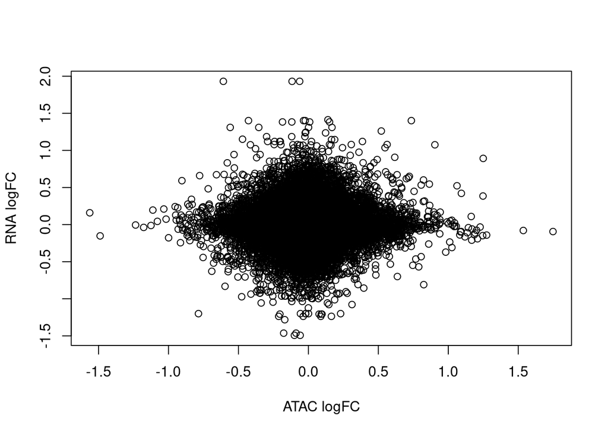

```r
# Correlation: all promoters
plot(df.combined$dea.logFC.x, df.combined$dea.logFC.y, xlab="ATAC logFC", ylab="RNA logFC")
```

```r
cor.test(df.combined$dea.logFC.x, df.combined$dea.logFC.y)
```

```
##
##  Pearson's product-moment correlation
##
## data:  df.combined$dea.logFC.x and df.combined$dea.logFC.y
## t = 3.3836, df = 35238, p-value = 0.0007163
## alternative hypothesis: true correlation is not equal to 0
## 95 percent confidence interval:
##  0.007582466 0.028457240
## sample estimates:
##        cor
## 0.01802182
```

```r
# Significant ATAC, what proportion also significant in RNA?
df.combined.sign.atac <- df.combined[df.combined$dea.padj.x < pthreshold,]
sum(df.combined.sign.atac$dea.padj.y < pthreshold) / nrow(df.combined.sign.atac)
```

```
## [1] 0
```

```r
# Significant RNA, what proportion also significant in ATAC?
df.combined.sign.rna <- df.combined[df.combined$dea.padj.y < pthreshold,]
sum(df.combined.sign.rna$dea.padj.x < pthreshold) / nrow(df.combined.sign.rna)
```

```
## [1] 0
```

```r
# Both significant
df.combined.sign.both <- df.combined[df.combined$dea.padj.x < pthreshold & df.combined$dea.padj.y < pthreshold,]
dim(df.combined.sign.both)
```

```
## [1]  0 27
```

## 5.8.2 Export differential genes for heatmaps (for deepTools etc.)

```r
# Whole gene and gene start BEDs
export.bed(genes.up, con = paste0(output, "genes.up.bed"))
export.bed(genes.down, con = paste0(output, "genes.down.bed"))

export.bed(genes.start.up, con = paste0(output, "genes.start.up.bed"))
export.bed(genes.start.down, con = paste0(output, "genes.start.down.bed"))
```

# 5.9.2 Pathway analysis of differentially accessible genes

```r
# Annotate peak-associated promoters for GO enrichment (using g:Profiler)
peaks.anno.up <- annotatePeak(readPeakFile(paste0(output, "up.bed")), tssRegion = c(-3000, 3000), TxDb = txdb, annoDb = "org.Mm.eg.db")
```

```
## >> preparing features information...      2025-06-30 15:35:42
## >> identifying nearest features...        2025-06-30 15:35:42
## >> calculating distance from peak to TSS...   2025-06-30 15:35:42
## >> assigning genomic annotation...        2025-06-30 15:35:42
## >> adding gene annotation...          2025-06-30 15:35:45
```

```
## >> assigning chromosome lengths           2025-06-30 15:35:45
## >> done...                    2025-06-30 15:35:45
```

```r
peaks.anno.down <- annotatePeak(readPeakFile(paste0(output, "down.bed")), tssRegion = c(-3000, 3000), TxDb = txdb, annoDb = "org.Mm.eg.db")
```

```
## >> preparing features information...      2025-06-30 15:35:45
## >> identifying nearest features...        2025-06-30 15:35:45
## >> calculating distance from peak to TSS...   2025-06-30 15:35:45
## >> assigning genomic annotation...        2025-06-30 15:35:45
## >> adding gene annotation...          2025-06-30 15:35:48
```

```
## >> assigning chromosome lengths           2025-06-30 15:35:48
## >> done...                    2025-06-30 15:35:48
```

```r
promoter_peaks.up <- subset(as.data.frame(peaks.anno.up), grepl("Promoter", annotation))
promoter_peaks.down <- subset(as.data.frame(peaks.anno.down), grepl("Promoter", annotation))
promoter_peaks.merged <- rbind(promoter_peaks.up, promoter_peaks.down)

go_up <- gost(query = promoter_peaks.up$ENSEMBL, organism = "mmusculus", ordered_query = FALSE, multi_query = FALSE, significant = TRUE, exclude_iea = FALSE, measure_underrepresentation = FALSE, evcodes = TRUE, user_threshold = 0.05, correction_method = "g_SCS", domain_scope = "annotated", custom_bg = NULL, numeric_ns = "", sources = "GO:BP", as_short_link = FALSE, highlight = TRUE)
go_down <- gost(query = promoter_peaks.down$ENSEMBL, organism = "mmusculus", ordered_query = FALSE, multi_query = FALSE, significant = TRUE, exclude_iea = FALSE, measure_underrepresentation = FALSE, evcodes = TRUE, user_threshold = 0.05, correction_method = "g_SCS", domain_scope = "annotated", custom_bg = NULL, numeric_ns = "", sources = "GO:BP", as_short_link = FALSE, highlight = TRUE)
go_merged <- gost(query = promoter_peaks.merged$ENSEMBL, organism = "mmusculus", ordered_query = FALSE, multi_query = FALSE, significant = TRUE, exclude_iea = FALSE, measure_underrepresentation = FALSE, evcodes = TRUE, user_threshold = 0.05, correction_method = "g_SCS", domain_scope = "annotated", custom_bg = NULL, numeric_ns = "", sources = "GO:BP", as_short_link = FALSE, highlight = TRUE)
```

```r
head(go_up$result[, c("p_value", "term_size", "query_size", "intersection_size", "term_name")])
```

```
##        p_value term_size query_size intersection_size
## 1 7.161479e-12      6873        362               165
## 2 4.979305e-11      6280        362               153
## 3 1.081349e-09      4907        362               126
## 4 4.377783e-09      4155        362               111
## 5 1.112188e-07      3272        362                91
## 6 4.649463e-07      1293        362                49
##                            term_name
## 1              developmental process
## 2   anatomical structure development
## 3 multicellular organism development
## 4                 system development
## 5           animal organ development
## 6             epithelium development
```

```r
head(go_down$result[, c("p_value", "term_size", "query_size", "intersection_size", "term_name")])
```

```
##        p_value term_size query_size intersection_size
## 1 1.315039e-10      6280        381               158
## 2 3.394969e-10      6873        381               167
## 3 2.374078e-09      4155        381               116
## 4 1.203796e-08      4907        381               128
## 5 1.163189e-06      4795        381               120
## 6 1.178568e-06      4796        381               120
##                            term_name
## 1   anatomical structure development
## 2              developmental process
## 3                 system development
## 4 multicellular organism development
## 5               cell differentiation
## 6     cellular developmental process
```

```r
head(go_merged$result[, c("p_value", "term_size", "query_size", "intersection_size", "term_name")], 10)
```

```
##         p_value term_size query_size intersection_size
## 1  1.864403e-23      6873        730               326
## 2  2.643011e-23      6280        730               306
## 3  1.152908e-19      4907        730               249
## 4  1.303280e-19      4155        730               222
## 5  9.189629e-16      3272        730               179
## 6  6.656237e-15      2781        730               158
## 7  3.360503e-14      4795        730               229
## 8  3.446102e-14      4796        730               229
## 9  1.362853e-13      6447        730               282
## 10 1.466162e-12      6095        730               267
##                                    term_name
## 1                      developmental process
## 2           anatomical structure development
## 3         multicellular organism development
## 4                         system development
## 5                   animal organ development
## 6         anatomical structure morphogenesis
## 7                       cell differentiation
## 8             cellular developmental process
## 9  positive regulation of biological process
## 10   positive regulation of cellular process
```

# 5.10.2 Motif Enrichment: TFs & Target Regulation in RNA-seq

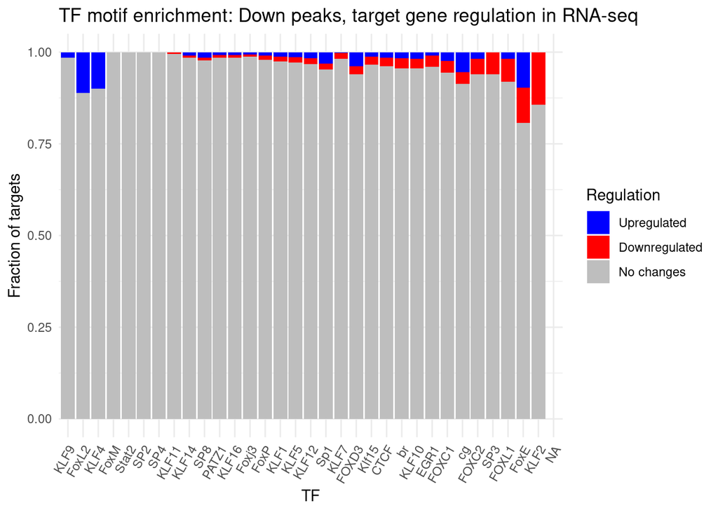

```r
# Use dorothea for TF target annotation
dorothea <- dorothea_mm[dorothea_mm$confidence %in% c("A", "B", "C", "D", "E"),]

# Example: load top TF motifs from AME output for downregulated peaks
tf.down <- read.delim(paste0(output, "ame_output_down/ame.tsv"))
topTFs <- 50
summarycols <- c("TF", "TargetsTotal", "TargetsInRNA", "TargetsPValueSign", "TargetsPadjSign", "Up", "Down", "NoChange",
                 "PercUp", "PercDown", "PercNoChange")
summary.down <- as.data.frame(matrix(NA, nrow = topTFs, ncol = length(summarycols), dimnames = list(NULL, summarycols)))

for (i in 1:topTFs) {
  pos <- grep(tf.down$motif_alt_ID[i], dorothea$tf, ignore.case = TRUE)
  # Skip if no targets found
  if (length(pos) == 0) {
    message("No dorothea targets found for motif: ", tf.down$motif_alt_ID[i])
    next
  }
  targets_symbols <- dorothea$target[pos]
  # Skip if no target symbols
  if (length(targets_symbols) == 0) {
    message("No gene symbols for motif: ", tf.down$motif_alt_ID[i])
    next
  }
  targets <- mapIds(org.Mm.eg.db, keys = targets_symbols, column = "ENSEMBL", keytype = "SYMBOL", multiVals = "first")
  # Remove any NAs from targets (no mapping)
  targets <- targets[!is.na(targets)]
  # Skip if no ENSEMBL IDs found
  if (length(targets) == 0) {
    message("No ENSEMBL IDs for motif: ", tf.down$motif_alt_ID[i])
    next
  }
  SE.RNA.sub <- SE.RNA[rownames(SE.RNA) %in% targets,]
  # If no overlap in RNA data, skip
  if (nrow(SE.RNA.sub) == 0) {
    message("No RNA-seq data for motif: ", tf.down$motif_alt_ID[i])
    next
  }
  res.sub <- rowData(SE.RNA.sub)$dea
  summary.down[i,] <- list(
    tf.down$motif_alt_ID[i], length(pos), nrow(SE.RNA.sub),
    sum(res.sub$PValue < pthreshold), sum(res.sub$padj < pthreshold),
    sum(res.sub$logFC > logthreshold), sum(res.sub$logFC < -logthreshold),
    nrow(SE.RNA.sub) - sum(res.sub$logFC > logthreshold) - sum(res.sub$logFC < -logthreshold),
    sum(res.sub$logFC > logthreshold)/nrow(SE.RNA.sub),
    sum(res.sub$logFC < -logthreshold)/nrow(SE.RNA.sub),
    (nrow(SE.RNA.sub) - sum(res.sub$logFC > logthreshold) - sum(res.sub$logFC < -logthreshold))/nrow(SE.RNA.sub)
  )
}
# Visualization: stacked barplot (Up/Down/NoChange) per TF
summary.down$TF <- factor(summary.down$TF, levels = summary.down$TF[order(summary.down$PercDown)])
summary.down.melted <- reshape2::melt(summary.down, id.vars = "TF", measure.vars = c("PercUp", "PercDown", "PercNoChange"))
ggplot(summary.down.melted, aes(x = TF, y = value, fill = variable)) +
  geom_bar(stat = "identity") +
  scale_fill_manual(values = c("PercUp" = "blue", "PercDown" = "red", "PercNoChange" = "grey"),
                    labels = c("Upregulated", "Downregulated", "No changes")) +
  labs(x = "TF", y = "Fraction of targets", fill = "Regulation") +
  ggtitle("TF motif enrichment: Down peaks, target gene regulation in RNA-seq") +
  theme_minimal() +
  theme(axis.text.x = element_text(angle = 60, hjust = 1))
```

## 5.11 Interpretation

This integrative analysis of chromatin accessibility (ATAC-seq) and gene expression (RNA-seq) in spermatogonial stem cells at PND15 following early-life stress (MSUS) reveals that stress induces widespread changes in chromatin accessibility. Both upregulated and downregulated regions were identified, with the most robust and statistically significant motif enrichment observed among downregulated peaks, specifically for STAT family transcription factor motifs, when peaks were selected using stringent, FDR-adjusted thresholds. This indicates that early-life stress is associated with decreased accessibility at key regulatory sites linked to immune and cytokine signaling pathways.  
For upregulated regions, no motifs remained significant after correction for multiple testing when using FDR-adjusted thresholds; however, enrichment for testis-specific and AP-1 family motifs was observed when a relaxed (unadjusted p-value) threshold was applied. This highlights that some biologically relevant regulatory signals may only become detectable with broader peak selection criteria.  
Pathway analysis further demonstrated that associations with developmental and differentiation processes are primarily seen when differentially accessible regions are defined using these relaxed thresholds, rather than more stringent criteria. Importantly, despite extensive chromatin remodeling, the correlation between chromatin accessibility changes and gene expression was minimal, and there was almost no overlap in significantly affected genes between ATAC-seq and RNA-seq datasets.  
Overall, these findings indicate that early-life stress leads to significant, motif- and pathway-specific changes in the epigenomic landscape of spermatogonial stem cells, most notably a reduction in accessibility at STAT-regulated loci. However, these chromatin changes are largely uncoupled from immediate transcriptional changes, suggesting a primed but not yet fully realized regulatory state. This poised chromatin configuration may underlie long-term functional consequences for germ cell development and future gene regulation.